## Health and Economic effects of Severe Weather in the United States

Shourya Maheshwari

10-10-2020

### Synopsis

This study examines the correlation between severe weather events and the level of damage they cause to property and lives. The data basis for this analysis comes from the U.S. National Oceanic and Atmospheric Administration’s (NOAA) storm database, which contains details of severe weather incidents including the type of incident, the time it occurred, the number of human injuries/fatalities and the monetary level of damage to property and crops between January 1950 and March 2016.

**Key questions to address:**

1. Across the United States, which types of events are most harmful with respect to population health?
2. Across the United States, which types of events have the greatest economic consequences?

### Data Processing

The data for this project was obtained in the form of a comma-separated-value file compressed via the bzip2 algorithm to reduce its size and found at:

https://d396qusza40orc.cloudfront.net/repdata%2Fdata%2FStormData.csv.bz2

The documentation can be found at:

https://d396qusza40orc.cloudfront.net/repdata%2Fpeer2_doc%2Fpd01016005curr.pdf

The variables from this dataset that were selected for this analysis include:

1. **EVTYPE**: Event Type
2. **Fatalities**: # of fatalities
3. **Injuries**: # of injuries

### **Set Required Libraries**

```r
library(ggplot2)
library(dplyr)
library(knitr)
```

### **Loading Storm Data**

Create Data Frame for event type, fatalities and injuries

```r
weatherdata <- read.csv("repdata_data_StormData.csv", header = TRUE, sep = ",")
weatherdataclean <- data.frame(weatherdata$EVTYPE,weatherdata$FATALITIES, weatherdata$INJURIES)
colnames(weatherdataclean) = c("EVTYPE", "FATALITIES", "INJURIES")
str(weatherdataclean)
```

```
## 'data.frame':    902297 obs. of  3 variables:
##  $ EVTYPE    : chr  "TORNADO" "TORNADO" "TORNADO" "TORNADO" ...
##  $ FATALITIES: num  0 0 0 0 0 0 0 0 1 0 ...
##  $ INJURIES  : num  15 0 2 2 2 6 1 0 14 0 ...
```

Create Data Frame for event type, property damage and crop damage

```r
damagedataclean <- data.frame(weatherdata$EVTYPE,weatherdata$PROPDMG, weatherdata$PROPDMGEXP, weatherdata$CROPDMG, weatherdata$CROPDMGEXP)

colnames(damagedataclean) = c("EVTYPE", "PROPDMG", "PROPDMGEXP", "CROPDMG", "CROPDMGEXP")
```

Derive damage amount based on metric summary (K = 1,000, M = 1,000,000, B = 1,000,000,000). Create new metric for combined property + crop damage.

```r
damagedataclean$PROPDMGMult <- ifelse (damagedataclean$PROPDMGEXP == "K", 1000, ifelse (damagedataclean$PROPDMGEXP == "M", 1000000, ifelse (damagedataclean$PROPDMGEXP == "B", 1000000000, 0)))

damagedataclean$PROPDMGAMT <- damagedataclean$PROPDMG*damagedataclean$PROPDMGMult

damagedataclean$CROPDMGMult <- ifelse (damagedataclean$CROPDMGEXP == "K", 1000, ifelse (damagedataclean$CROPDMGEXP == "M", 1000000, ifelse (damagedataclean$CROPDMGEXP == "B", 1000000000, 0)))

damagedataclean$CROPDMGAMT <- damagedataclean$CROPDMG*damagedataclean$CROPDMGMult

damagedataclean$TOTALDMGAMT <- damagedataclean$PROPDMGAMT+damagedataclean$CROPDMGAMT
```

## Results

### 1. Which types of events are most harmful to population health?

For the purpose of this analysis, we will interpret “harmful” as having the most fatalities OR most injuries. There are 2 outputs below. In terms of “types of events”, we will examine individual event types and not groups of event types.

### **Fatalities**

Below is a summary of events based on total number of fatalities by event type. Only the top 10 events are shown.

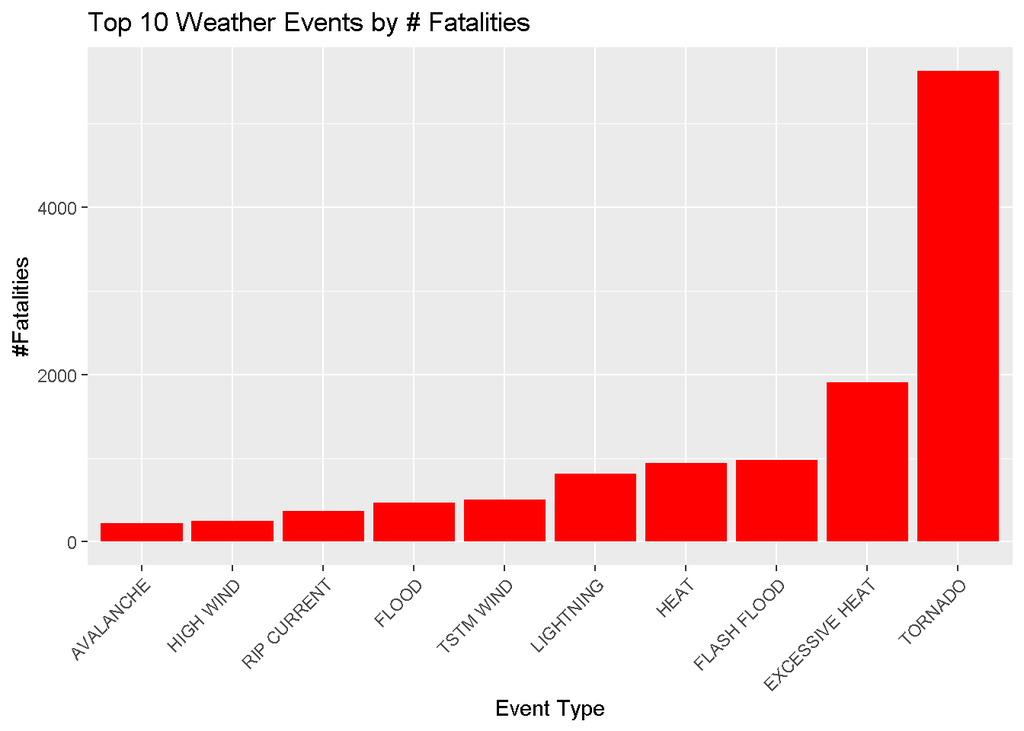

```r
weatherfatalities <- aggregate(weatherdataclean$FATALITIES, by = list(weatherdataclean$EVTYPE), FUN = sum, na.rm = TRUE)
colnames(weatherfatalities) = c("EVTYPE", "FATALITIES")
weatherfatalities <- weatherfatalities[order(-weatherfatalities$FATALITIES),]
topweatherfatalities <- weatherfatalities[1: 10, ]

p<- ggplot(topweatherfatalities, aes(x=reorder(EVTYPE, FATALITIES), y=FATALITIES))
p+geom_bar(stat = "identity", fill = "red")+ ggtitle("Top 10 Weather Events by # Fatalities")+labs(x = "Event Type", y="#Fatalities") +theme(axis.text.x = element_text(angle=45, hjust=1))
```

Based on the information shown above, Tornadoes are the most harmful events to population health based on total number fatalities.

### **Injuries**

Below is a summary of events based on total number of injuries by event type. Only the top 10 events are shown.

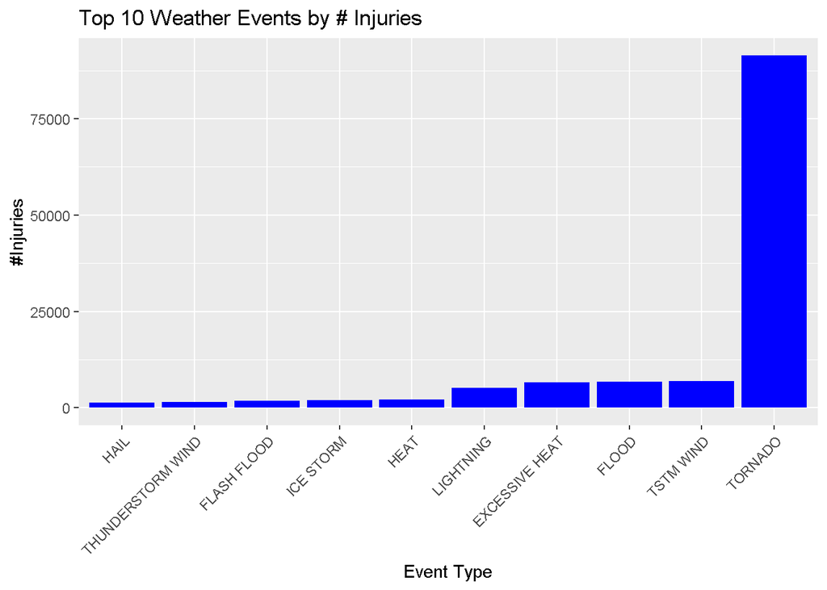

```r
weatherinjury <- aggregate(weatherdataclean$INJURIES, by = list(weatherdataclean$EVTYPE), FUN = sum, na.rm = TRUE)
colnames(weatherinjury) = c("EVTYPE", "INJURIES")
weatherinjury <- weatherinjury[order(-weatherinjury$INJURIES),]
topweatherinjury <- weatherinjury[1: 10, ]

q<- ggplot(topweatherinjury, aes(x=reorder(EVTYPE, INJURIES), y=INJURIES))
q+geom_bar(stat = "identity", fill = "blue")+ ggtitle("Top 10 Weather Events by # Injuries")+labs(x = "Event Type", y="#Injuries") +theme(axis.text.x = element_text(angle=45, hjust=1))
```

Based on the information shown above, Tornados are the most harmful events to population health based on total number injuries.

### 2. Which types of events have the greatest economic consequences?

Below is a summary of events sames on total damage by event type. Only the top 10 events are shown.

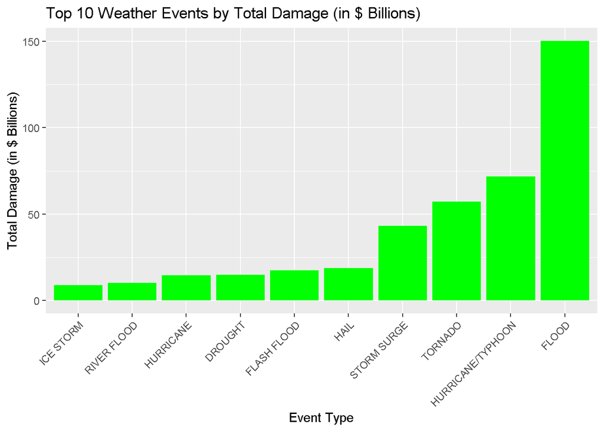

```r
TOTALDMGAMT <- aggregate(damagedataclean$TOTALDMGAMT, by = list(damagedataclean$EVTYPE), FUN = sum, na.rm = TRUE)
colnames(TOTALDMGAMT) = c("EVTYPE", "TOTALDMGAMT")
TOTALDMGAMT <- TOTALDMGAMT[order(-TOTALDMGAMT$TOTALDMGAMT),]
TOPTOTALDMGAMT <- TOTALDMGAMT[1: 10, ]

r<- ggplot(TOPTOTALDMGAMT, aes(x=reorder(EVTYPE, TOTALDMGAMT/1000000000), y=TOTALDMGAMT/1000000000))
r+geom_bar(stat = "identity", fill = "green")+ ggtitle("Top 10 Weather Events by Total Damage (in $ Billions)")+labs(x = "Event Type", y="Total Damage (in $ Billions)") +theme(axis.text.x = element_text(angle=45, hjust=1))
```

Based on the information shown above, Floods have the greatest economic consequences based on total dollars of property and crop damage.

## Conclusion

Tornadoes are the most harmful events to population health, both in terms of fatalities and injuries.

Floods have the greatest economic consequences based on total dollars of damage.